# Day 1: Introduction to Mathematical Optimization

— How to understand and formulate a mathematical optimization problem

Bo Yang

03/28/2020

## Optimization:

To optimize (or minimize) a **continus** function $f(\textbf{x}):\textbf{R}^n\rightarrow\textbf{R}$ is to find $\textbf{x}_0\in A\subseteq\textbf{R}^n$ so that $f(\textbf{x}_0)\le f(\textbf{x})$ for all $\textbf{x}\in A\subseteq\textbf{R}^n$.

Actually, optimization is a very huge field. Here, I’ll just show you a brief introduction in two or three lectures. My lecture is based on our handout, but I will present it in the different way. In Day 1, let me emphasize the importance of formulating an optimization problem rigorously.

### 1. Objective Function

1. Function (continuous with multiple variables and having a scalar value): $f(\textbf{x}):\textbf{R}^n\rightarrow\textbf{R}$.  
   How to choose it in practice is interesting and tricky. See part.1b, 4b, 4c below.
2. Mininization (or Maximization):
   They can be converted into each other by changing the sign of objective function as below:
   $$\text{max}_{\textbf{x}\in A}
   f(\textbf{x})\iff \text{min}_{\textbf{x}\in
   A}[-f(\textbf{x})]$$
3. Equivalent Objective Functions:
   There are some other equivalent objective functions. For example, note that $x^3$ is an increasing function,
   $$\text{min}_{\textbf{x}\in A}
   f(\textbf{x})\iff \text{min}_{\textbf{x}\in
   A}[f(\textbf{x})]^3.$$
   Or, if $f(\textbf{x})$ is always positive,
   $$\text{max}_{\textbf{x}\in A} f(\textbf{x})\iff
   \text{max}_{\textbf{x}\in A}\log[f(\textbf{x})]$$
   because $\log()$ is also an increasing function. It will be used in part.4f and 4g.

### 2. Changing Variables

1. During the optimization, which variables are changing and which variables are fixed like constants?  
   See part.4a, 4b, 4c below.
2. Dimension, Domain and Constraints:
- Dimension: the dimension of changing variables, i.e., $n$ above;
- Domain (Search Space or Choice Set): the range of changing variables, i.e., $A$ above;
- Constraint: equalities or inequalities that the changing variables have to satisfy, such as:
  $$\text{min}_{(x, y)\in\textbf{R}^2\text{ and
  }x^2 + y^2 = 1} f(x, y),$$
  where $x^2+y^2 = 1$ is a constraint.
3. The simplest case discussed in this introduction:
- dimension satisfies $1\le n\le 2$;
- domain always looks like a box, such as $(x, y)\in A = [a_1, b_1]\times[a_2, b_2]\subseteq\textbf{R}^2$, i.e., $a_1\le x\le b_1$ and $a_2\le y\le b_2$, where the limits $a_i, b_i (i = 1, 2)$ could be finite or infinite;
- no constraint.

### 3. Formulation:

Identify every element in part.1 and 2 from the standard form (in 2-D case):

$$\text{min}_{(x, y)\in
A\subseteq\textbf{R}^2} f(x, y; a, b, ...)$$
Then, you can define the objective function in R. See part.4 for more details.

### 4. Application in Statistics: Estimation and Regression

1. Simple Linear Regression (SLR) (in handout)
- Motivation: If you forget this fundamental SLR, [watch the video (just from 0:00 to 3:17)](https://www.youtube.com/watch?v=coQAAN4eY5s) first. Also, see the graph below:

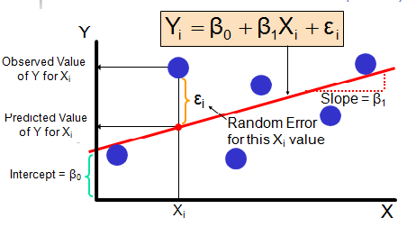

  to understand SLR geometrically. Then, formulate the related optimization problem **strictly** as shown below:
- Objective function:
  $$SSE\left(\hat{\beta}_0, \hat{\beta}_1; \{(x_i,
  y_i)\}\right)
  = \sum e_i^2 = \sum (y_i - \hat{y_i})^2 = \sum \left(y_i -
  (\hat{\beta_0} + \hat{\beta_1}x_i)\right)^2$$
- Goal: Minimize $SSE$
- Changing variables: $\hat{\beta}_0, \hat{\beta}_1$, which determine the best fitting line.
- Fixed variables: $(x_i, y_i)$, which are fixed observed data.
- Dimension: $n = 2$, from $\hat{\beta}_0, \hat{\beta}_1$.
- Domain: $-\infty < \hat{\beta}_0 < +\infty, -\infty < \hat{\beta}_1 < +\infty$, i.e., $A = \textbf{R}^2$.
- Constraint: none
- Definition of $SSE()$ in R for the future use:

```r
# usual least squares function SSE()
# beta is 2-dim and changing
# x, y are fixed and should be considered as constants
SSE = function(beta, x, y) {
  return(sum((y - (beta[1] + beta[2] * x))^2))
}

# Optional task: If you like, you can compute its gradient by calculus and define it in R.
```

2. Robust Regression (in HW1 part1)
- Motivation: First, review STAT304 HW3 part1, [Jackknife method](http://pages.stat.wisc.edu/~byang/304/3/HW3.html) to understand the effects of the annoying outliers (Alaska, instead of Texas) in SLR. In order to weaken the outlier’s effect (Robust Regression), we are going to find a better objective function $Tukey()$ with $\rho()$ function, instead of square function. Then, read HW1 part1 carefully and if you like, [watch this video](https://www.youtube.com/watch?v=7a_6roLjwaA), where the motivation of the new objective function is explained clearly, but the notation is slightly different ($\rho()$ function is called Huber M Estimator). At last, formulate the related optimization problem **strictly** as shown below:
- Objective function: $Tukey\left(\beta_0, \beta_1; \{(x_i, y_i)\}\right)$
- Goal: Minimize $Tukey()$
- Changing variables: $\beta_0, \beta_1$, which determine the best fitting line.
- Fixed variables: $(x_i, y_i)$, which are fixed observed data.
- Dimension: $n = 2$, from $\beta_0, \beta_1$.
- Domain: $-\infty < \beta_0 < +\infty, -\infty < \beta_1 < +\infty$, i.e., $A = \textbf{R}^2$.
- Constraint: none
- Definition of $Tukey()$ and others in R for the future use:

```r
# new objective function S() based on Robust Regression
# beta is 2-dim and changing
# x, y are fixed and should be considered as constants
# Need two auxiliary functions rho() and Tukey() to replace the square function
rho = function(t, k) { # k is the threshold
  # translate rho()'s formula in HW1 part1 to R code here
}

Tukey = function(beta, x, y){
  # translate Tukey()'s formula in HW1 part1 to R code here
  # might need to call rho() defined above
}

# Also, for the future use, define two more derivative functions rho.prime() and Tukey.gr()
rho.prime = function(t, k) { # k is the threshold
  # translate rho.prime()'s formula in HW1 part1 to R code here
}

Tukey.gr = function(beta0, beta1){
  # translate Tukey.gr()'s formula in HW1 part1 to R code here
  # might need to call rho.prime() defined above
}
```

3. Least Absolute Deviation Regression (LAD) (in HW2 part1)
- Motivation: First, review STAT304 HW3 part1, [Jackknife method](http://pages.stat.wisc.edu/~byang/304/3/HW3.html) to understand the effects of the annoying outliers (Alaska, instead of Texas) in SLR. In order to weaken the outlier’s effect (Robust Regression), we are going to find a better objective function $LAD()$ with the absolute value function $abs()$, instead of square function. Then, read HW2 part1 carefully and if you like, [watch this video](https://www.youtube.com/watch?v=7a_6roLjwaA), where the motivation and disadvantage of the new objective function is explained clearly, but the notation is slightly different. Remember that $LAD()$ contains $abs()$, which is not differentiable everywhere. So, $LAD()$ is also not differentiable everywhere. At last, formulate the related optimization problem **strictly** as shown below:
- Objective function: $LAD\left(\beta_0, \beta_1; \{(x_i, y_i)\}\right)$, not differentiable everywhere.
- Goal: Minimize $LAD$
- Changing variables: $\beta_0, \beta_1$, which determine the best fitting line.
- Fixed variables: $(x_i, y_i)$, which are fixed observed data.
- Dimension: $n = 2$, from $\beta_0, \beta_1$.
- Domain: $-\infty < \beta_0 < +\infty, -\infty < \beta_1 < +\infty$, i.e., $A = \textbf{R}^2$.
- Constraint: none
- Definition of $LAD()$ in R for the future use:

```r
# new objective function LAD() based on LAD
# beta is 2-dim and changing
# x, y are fixed and should be considered as constants
LAD = function(beta, x, y) {
  # translate LAD()'s formula in HW2 part1 to R code here
}
# There is no need to define any derivative functions.
```

4. Problems in Group Practices  
   They are quite straightforward. Do them first with your teammates or discuss them on Piazza.
5. Exponential Smoothing (in HW1 part2)
- Motivation: see HW1 part2
- Objective function: $FE\left(\beta; Y_i\right)$, sum of square, differentiable everywhere. But its derivative is difficult to calculate.
- Goal: Minimize $FE$
- Changing variables: $\beta$, which determine the best exponential smoothing model.
- Fixed variables: $Y_i$, which are fixed observed data.
- Dimension: $n = 1$, from $\beta$.
- Domain: find it by yourself.
- Constraint: none
- Definition of $FE()$ in R for the future use:

```r
# new objective function FE() based on Exponential Smoothing
# beta is 1-dim and changing
# Y are fixed and should be considered as constants
FE = function(beta, Y) {
  # translate FE()'s formula in HW2 part2 to R code here
}
# There is no need to define any derivative functions.
```

6. Maximum Likelihood Estimation (MLE) (in HW1 part3a)
- Motivation: see HW1 part3a
- Objective function: First, it should be the likelihood function $L()$. Then, for the mathematical convenience, we choose the equivalent objective function: log likelihood function $l() = log(L())$ (see part.1c).
- Goal: find it by yourself.
- Changing variables: find it by yourself **carefully**.
- Fixed variables: find it by yourself **carefully**.
- Dimension: find it by yourself.
- Domain: find it by yourself.
- Constraint: find it by yourself.
- Definition of $l()$ in R for the future use:

```r
# new objective function FE() based on MLE for Normal Distribution
#
#
l = function(...) {
  # translate l()'s formula in HW1 part3a to R code here
}
# There is no need to define any derivative functions unless you are good at the chain rules.
```

7. Logistic Regression (in HW1 part3b)
- Motivation: see HW1 part3b
- Objective function: First, it should be the likelihood function $L()$. Then, for the mathematical convenience, we choose the equivalent objective function: log likelihood function $l() = log(L())$ (see part.1c).
- Goal: find it by yourself.
- Changing variables: find it by yourself **carefully**.
- Fixed variables: find it by yourself **carefully**.
- Dimension: find it by yourself.
- Domain: find it by yourself.
- Constraint: find it by yourself.
- Definition of $l()$ in R for the future use:

```r
# new objective function l() based on MLE in Logistic Regression
#
#
l = function(...) {
  # translate FE()'s formula in HW1 part3b to R code here
}
# There is no need to define any derivative functions unless you are good at the chain rules.
```